# Estimating Causal Effect of Government Intervention to Mobility

Kenneth Lee

23/09/2020

## Introduction

We would like to estimate the causal effect of governement intervention, collected from University of Washington, on the mobility signal, produced by covidcast signal by using Baysiean structural time-series model. The question we want to answer is: how the mobility signal was increased/decreased by various state policies?

## Model assumption

- We assume that there is a set control time series that were themselves not affected by the intervention.
- The model also assumes that the relationship between covariates and treated time series, as established during the pre-period, remains stable throughout the post-period.

## Implementation

- We will use the full-time mobility signal as the treated time series. We then select the following as our control time-series: average temperature, holiday (binary), weekend indicator (binary).

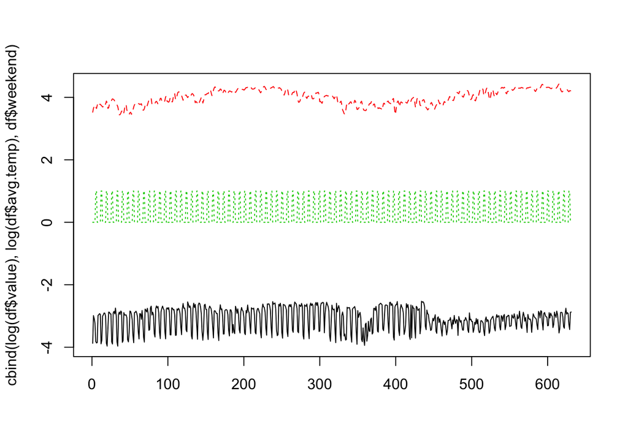

### Visualize the causal estimate

We show that the causal estimate by counterfactual prediction (blue line) and observations (black line)

```r
impact <- CausalImpact(data, pre.period, post.period)
```

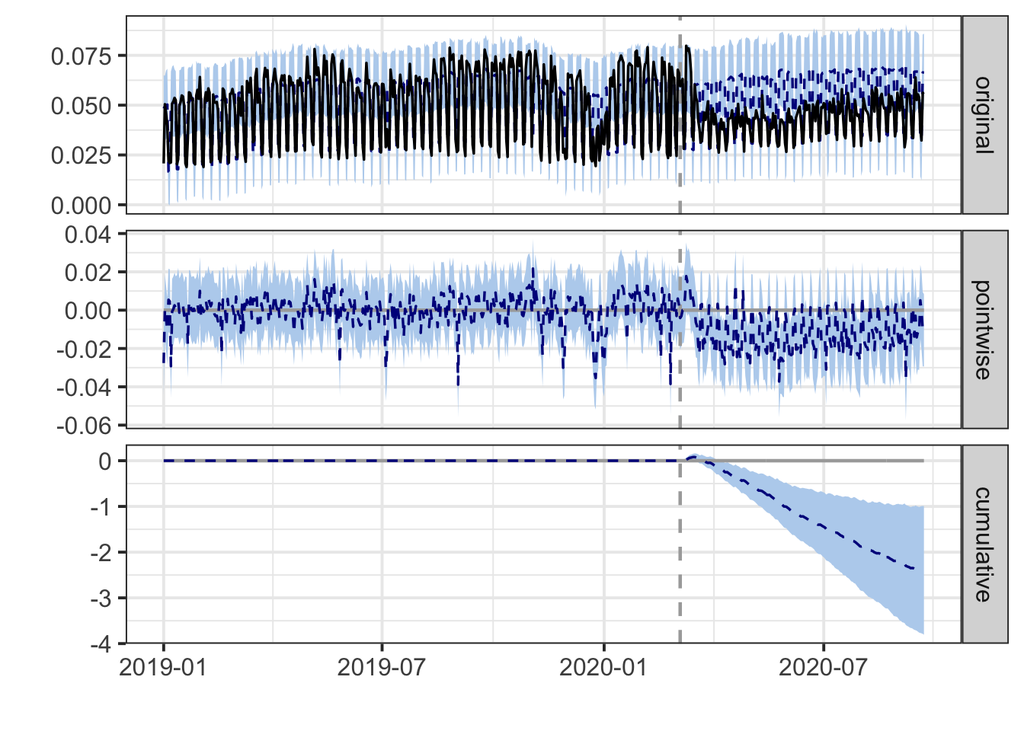

```r
plot(impact)
```

### Interpret the result

```
## Posterior inference {CausalImpact}
##
##                          Average             Cumulative
## Actual                   0.044               8.895
## Prediction (s.d.)        0.056 (0.0036)      11.314 (0.7294)
## 95% CI                   [0.049, 0.063]      [9.887, 12.702]
##
## Absolute effect (s.d.)   -0.012 (0.0036)     -2.419 (0.7294)
## 95% CI                   [-0.019, -0.0049]   [-3.806, -0.9919]
##
## Relative effect (s.d.)   -21% (6.4%)         -21% (6.4%)
## 95% CI                   [-34%, -8.8%]       [-34%, -8.8%]
##
## Posterior tail-area probability p:   0.00109
## Posterior prob. of a causal effect:  99.89071%
##
## For more details, type: summary(impact, "report")
```

[output not shown]

### Reference

- “CausalImpact 1.2.1, Brodersen et al., Annals of Applied Statistics (2015). http://google.github.io/CausalImpact/”